# Cuaderno 2: Descriptivo

Aurora Baluja

24 de agosto de 2017

## Introducción

#### Copiar las carpetas y subcarpetas en el ordenador

Todo el tutorial se puede descargar en *.ZIP* desde este [enlace](https://github.com/aurora-mareviv/Rstarters/archive/master.zip).

**Nota**: Este documento **RMD** y su HTML nos permiten conservar los comandos utilizados: para usarlos cuando nos hagan falta, pero integrados con texto de forma más visual que un simple script de R con comentarios (#). Verás que al principio del RMD hay incluido un cabecero donde se pueden dar algunos toques de apariencia (como usar la paleta *tango* de colores). Ese cabecero no está escrito en R, por tanto no se debe modificar de ninguna forma, ya que incluso los espacios en blanco tienen su significado.

Para importar los datos de nuestra base, usaremos el siguiente [método](http://www.r-tutor.com/r-introduction/data-frame/data-import).

Este es tu directorio de trabajo:

```r
getwd()
```

- Debemos fijarnos en que el directorio/carpeta de trabajo coincida con aquel que queremos y en el que están los datos. En R se llama el “working directory”.
- Para lograr eso en un documento *.RMD*, la mejor solución es que *todo* esté en una unas carpetas determinadas: scripts, datos etc…
- Guardo las rutas que me interesan en una variable de R. Tiene el formato “character” que significa que es una cadena de texto sencillamente.

```r
# la carpeta donde esta el cuaderno
wdir <- getwd()
# la carpeta donde guardo los datos
datadir <- paste(wdir, "/data", sep="")
# la carpeta donde guardo las imagenes
plotdir <- paste(wdir, "/rplot", sep="")
# bonus: la carpeta inmediatamente por encima
wdirUp <- gsub("\\Rmarkdown_Project", "", wdir)
```

## Importación de datos

Las rutas donde se hallan los datos las uso para el comando de importación (de momento vamos a obviar la parte de importación de Excel)

- Si tu archivo está en formato *.csv* por ejemplo, necesitas este comando:

```r
dataname <- "data-training_acath.csv"
mydata <- read.csv(paste(datadir, "/", dataname, sep=""),
         header = TRUE,
         sep = "\t",
         dec = ",")
# sep = "\t" si las columnas estan separadas por un tabulador (recomendado)
# sep = "," si las columnas estan separadas por una coma
# sep = ";" si las columnas estan separadas por un punto y coma.... etc

# dec = "," si los decimales son con forma de coma
# dec = "." si los decimales son con forma de punto
```

- Echa un vistazo a la ayuda de la función de importación con el comando de consola: `?read.csv`.

### Los datos `acath`:

Sacados del siguiente [enlace](http://biostat.mc.vanderbilt.edu/wiki/Main/DataSets). Los datos se hallan explicados [aquí](http://biostat.mc.vanderbilt.edu/wiki/pub/Main/DataSets/Cacath.html).

| Name | Labels | Units | Storage | NAs |
| --- | --- | --- | --- | --- |
| sex |  |  | double | 0 |
| age | Age | Year | double | 0 |
| cad.dur | Duration of Symptoms of Coronary Artery Disease |  | double | 0 |
| choleste | Cholesterol | mg % | double | 1246 |
| sigdz | Significant Coronary Disease by Cardiac Cath |  | double | 0 |
| tvdlm | Three Vessel or Left Main Disease by Cardiac Cath |  | double | 3 |

## Resumen de datos

Para conocer bien una base de datos en R, hay una serie de comandos que debemos usar:

```r
class(mydata) # el formato de los datos en R
```

```
   [1] "data.frame"
```

```r
nrow(mydata) # numero de filas
```

```
   [1] 3504
```

```r
ncol(mydata) # numero de columnas
```

```
   [1] 6
```

```r
row <- nrow(mydata) # almaceno el num de filas en la variable "row"
col <- ncol(mydata)
```

- La base de datos tiene 3504 filas y 6 columnas.

```r
names(mydata) # nombres de las variables de mis datos
```

```
   [1] "sex"      "age"      "cad.dur"  "choleste" "sigdz"    "tvdlm"
```

```r
names(mydata)[2] # nombre de la segunda variable
```

```
   [1] "age"
```

- Debemos ver un resumen completo de nuestros datos. Como `summary(mydata)` muchas veces es demasiado amplio para mostrarlo todo aquí, lo podemos reducir a unas pocas variables: todas las filas ( , …) y las columnas (1,2). Podemos escoger las filas y columnas que queramos:
- He inactivado (con `eval=FALSE`) algunos comandos para que no salten en el documento final, pero los puedes mirar en la consola uno por uno:

```r
View(mydata) # visualizar datos
fix(mydata) # modificar datos
summary(mydata)
summary(mydata[ , ]) equivale al comando anterior
```

```r
summary(mydata[ , c(1,2)])
```

```
         sex              age
    Min.   :0.0000   Min.   :17.00
    1st Qu.:0.0000   1st Qu.:46.00
    Median :0.0000   Median :52.00
    Mean   :0.3136   Mean   :52.28
    3rd Qu.:1.0000   3rd Qu.:59.00
    Max.   :1.0000   Max.   :82.00
```

### Solución de problemas de formato de las variables

R no siempre importa las variables como queremos. Por ejemplo, si queremos cambiar una variable numérica como `sex` a factor, ponemos:

```r
mydata$sex <- ordered(mydata$sex,
levels = c(0,1),
labels = c("Hombre", "Mujer"))
```

```r
mydata[, 2] <- as.numeric(mydata[, 2]) # y de nuevo a numerica.
# age es la variable num. 2
```

## Estadistica descriptiva

Ya tenemos nuestros datos importados  
Ahora, debemos calcular:

- Frecuencias de las variables no-numéricas (factores)
- Resumen de las variables numéricas

```r
summary(mydata$sex)
```

```
   Hombre  Mujer
     2405   1099
```

```r
# Porcentaje de hombres:
summary(mydata$sex)[1] / (summary(mydata$sex)[1] + summary(mydata$sex)[2]) * 100
```

```
     Hombre
   68.63584
```

```r
# Porcentaje de mujeres:
summary(mydata$sex)[2] / (summary(mydata$sex)[1] + summary(mydata$sex)[2]) * 100
```

```
      Mujer
   31.36416
```

```r
summary(mydata$age)
```

```
      Min. 1st Qu.  Median    Mean 3rd Qu.    Max.
     17.00   46.00   52.00   52.28   59.00   82.00
```

```r
# Mediana:
summary(mydata$age)[3]
```

```
   Median
       52
```

### Ejercicio 1:

Haz trozos de código a continuación, con los resúmenes (usando `summary`) de las variables de la base de datos.

## Gráficos

Así como es importante resumir los datos mediante números y texto, lo es igualmente el resumen mediante los [gráficos](http://ggplot2.org/book/qplot.pdf):

La función `plot` de R tiene muchas opciones, pero es mucho más flexible la función `qplot`del paquete `ggplot2` (gracias al mejor “profe de R” [Hadley Wickham](http://hadley.nz/)).

- Los factores (variables no-numéricas) se representarán mediante diagramas de **barras**:

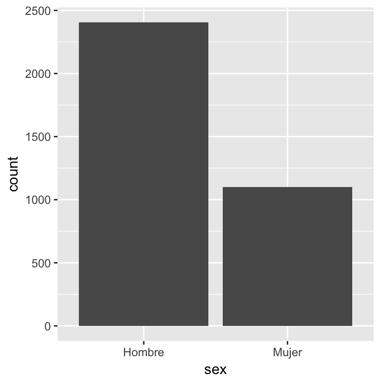

```r
library(ggplot2)
qplot(sex, data = mydata, geom = "bar")
```

- Las variables numéricas se representarán mediante **histogramas**:

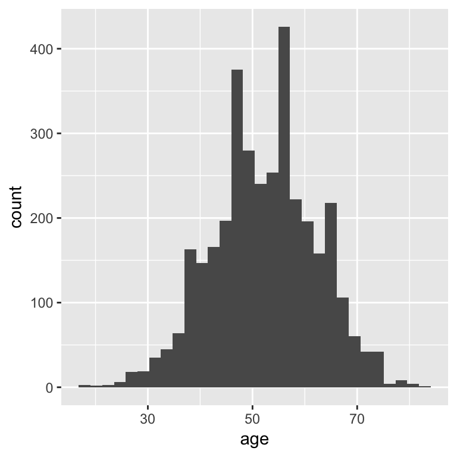

```r
qplot(age, data = mydata, geom = "histogram")
```

- Se puede cambiar la apariencia del gráfico muy fácilmente:

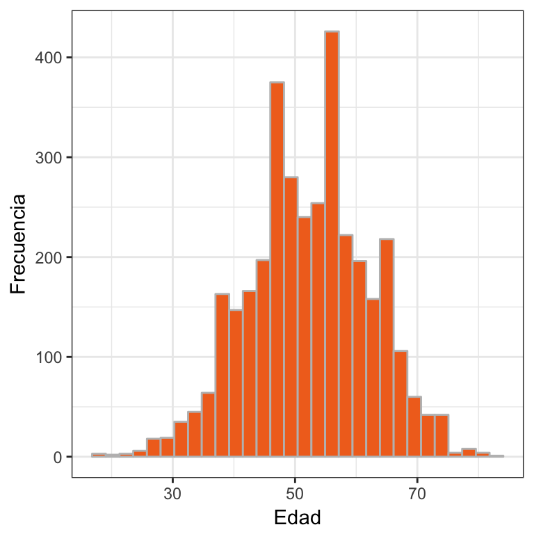

```r
# Los graficos tambien se pueden guardar dentro de objetos:
grafo <- qplot(age, data = mydata,
      geom="histogram",
      xlab="Edad", # nombre del eje x
      ylab="Frecuencia", # nombre del eje y
      fill=I("#F17022"), # color de relleno (anaranjado)
      col=I("grey")) + # color de linea (gris)
  theme_bw() # con "+ theme_bw()" le ponemos fondo blanco

grafo
```

- En cuanto a las paletas, la abanico completo de colores se consulta [aquí](http://www.w3schools.com/colors/colors_picker.asp), y la paleta **tango** [aquí](http://tango.freedesktop.org/Tango_Icon_Theme_Guidelines) y [aquí](http://www.colorcombos.com/tags/colors/tango).
- R y `ggplot2` también permiten cruzar una variable continua con un factor:

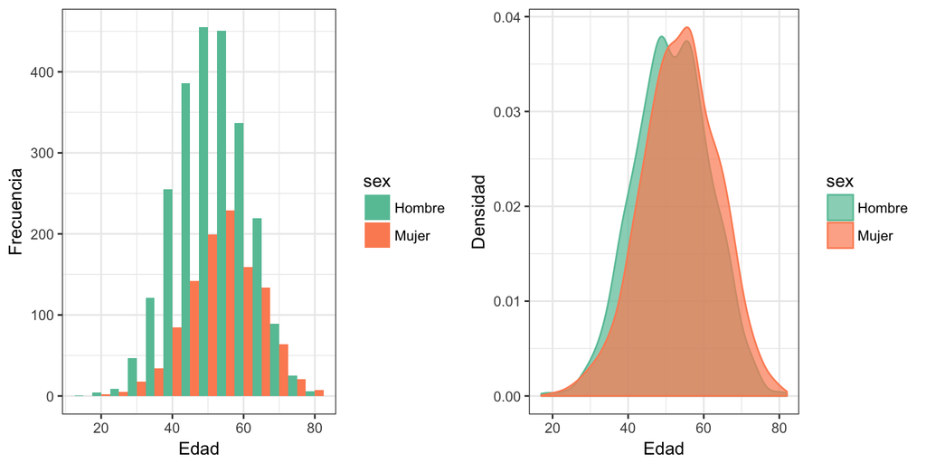

```r
library(RColorBrewer) # varias paletas de color
require(gridExtra)

grafo2 <- ggplot(mydata, aes(x=age, fill=sex)) +
  geom_histogram(position="dodge", binwidth = 5) +
  xlab("Edad") +
  ylab("Frecuencia") +
  theme_bw() +
  scale_colour_brewer(palette = "Set2") + # cambiamos la paleta de colores de linea
  scale_fill_brewer(palette = "Set2") # cambiamos la paleta de colores de relleno

grafo3 <- qplot(age, data = mydata,
      geom="density",
      xlab="Edad",
      ylab="Densidad",
      fill=sex, # color de relleno (segun los niveles de factor)
      col=sex, # color de linea (segun los niveles de factor)
      alpha=I(0.7)) + # transparencia de las capas, va entre 0 y 1
  theme_bw() +
  scale_colour_brewer(palette = "Set2") +
  scale_fill_brewer(palette = "Set2")

grid.arrange(grafo2, grafo3, ncol=2) # poner un grafico junto al otro en 2 columnas
```

- Hay distintas paletas de R para este tipo de gráficos. Las del paquete `RColorBrewer`que hemos empleado están aquí.
- Para representar 2 variables numéricas, tenemos el **scatterplot** (diagrama de dispersión)

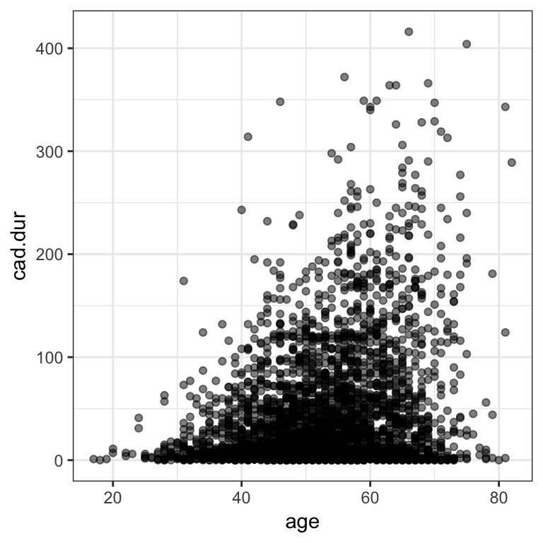

```r
qplot(age, cad.dur, data = mydata,
      alpha=I(0.5)) +
  theme_bw()
```

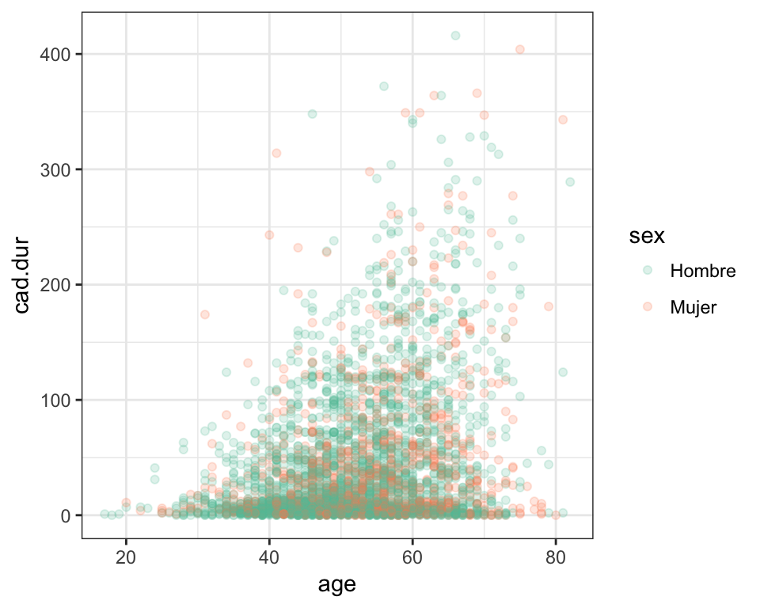

```r
qplot(age, cad.dur, data = mydata,
      alpha=I(0.2),
      col=sex) + # puntos coloreados por niveles de un factor
  theme_bw() +
  scale_colour_brewer(palette = "Set2") +
  scale_fill_brewer(palette = "Set2")
```

### Ejercicio 2:

Elabora un gráfico adecuado para cada tipo de variable de la base de datos. Recuerda que puedes controlar el tamaño de los mismos:

Experimenta con el cambio de color de los elementos, cambio de títulos de los ejes… etc.

## Normalidad

Esto sólo se refiere a las variables numéricas. En el caso de la homocedasticidad, una variable numérica será (o no) homocedástica respecto a un factor.

- Examinaremos la normalidad mediante el test de Shapiro-Wilk. Si el p-valor del test es < 0.05, diremos que la variable **no es normal/ gaussiana**.

```r
# shapiro.test(mydata$age)
shapiro.test(mydata$age)
```

```
    Shapiro-Wilk normality test

   data:  mydata$age
   W = 0.9978, p-value = 7.125e-05
```

```r
shapi <- shapiro.test(mydata$age)
pvalor.redondeo <- round(shapi$p.value, 3) # redondea hasta 3 decimales el valor p
```

- El **test de Shapiro** detecta que la variable no es normal (p-valor = 0).
- Sin embargo, a veces este test detecta erróneamente variables que podrían perfectamente funcionar como normales. Para ello, nos apoyaremos en un gráfico de normalidad, o [q-q plot](https://en.wikipedia.org/wiki/Q%E2%80%93Q_plot).

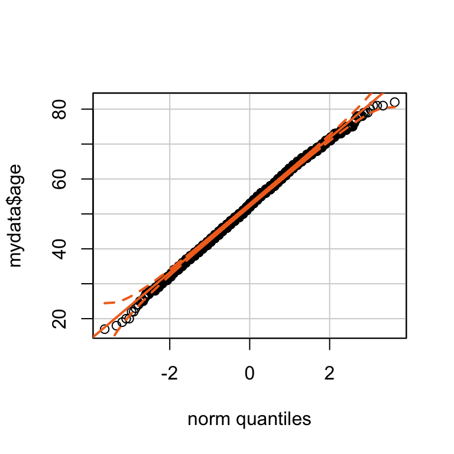

```r
library(car)
# qqPlot(mydata$age)
qqPlot(mydata$age, col.lines="#F17022")
```

- No hay una desviación importante de la línea de normalidad, por lo que consideraremos que la variable es normal (a pesar de lo que dice el test de Shapiro-Wilk).

### Ejercicio 3:

Comprueba si las variables numéricas de los datos cumplen la normalidad.

## Homocedasticidad

En el caso de la homocedasticidad, una variable numérica será (o no) homocedástica respecto a un factor.  
Esto quiere decir que la varianza de la variable numérica es la misma para cada nivel del factor por el que es dividida.

- Examinaremos la homocedasticidad mediante el test de Levene. Si el p-valor del test es < 0.05, diremos que la variable es **heterocedástica**.

```r
# levene.test(mydata$age)
leveneTest(mydata$age, mydata$sex, center=median)
```

```
   Levene's Test for Homogeneity of Variance (center = median)
           Df F value Pr(>F)
   group    1  0.0203 0.8868
         3502
```

```r
leve <- leveneTest(mydata$age, mydata$sex, center=median)
redondeo.levene <- round(leve[1,3], 4)
```

- La variable edad es homocedástica con respecto al sexo de los pacientes (p-valor = 0.8868). **Quiere decir que la varianza de la edad en hombres es similar a la varianza de las mujeres**.

### Ejercicio 4:

Comprueba si las variables numéricas de la base son homocedásticas respecto a algún factor (no hace falta cruzar todas las variables numéricas contra todos los factores, sino aquellos cruces que te parezcan más interesantes).

### Ejercicio 5. Datos propios:

#### CSV

Antes de nada, pega el archivo `Tabla1vt.csv` en el directorio “**data**”.  
Impórtalo utilizando el comando visto más arriba:

```r
dataname <- "Tabla1vt.csv"
mydata <- read.csv(paste(datadir, "/", dataname, sep=""),
         header = TRUE,
         sep = "\t",
         dec = ",")
```

#### Excel

```r
dataname <- "Tabla1vt.xlsx"  # el nombre del archivo
rutaxl <- paste(datadir, "/", dataname, sep="")  # la ruta completa al archivo

library(readxl)
mydata <- read_excel(rutaxl, sheet = 1)  # importa la primera hoja del excel
```

Una vez importado, examina los nombres que tienen las variables dentro de R. ¿Sería conveniente corregir alguno para que fuesen más legibles?.

```r
names(mydata)
```

```
    [1] "Tipo Cx"                "Edad"
    [3] "Fecha Intervencion"     "Tiempo de Cl. Ao (min)"
    [5] "T. CEC (min)"           "EUROSCORE T."
    [7] "EUROSCORE L."           "Estadio Cr"
    [9] NA                       "FGR<45"
   [11] NA                       "Si FGR <45, Valor"
   [13] "Anemia"                 NA
   [15] "Hb g/dL"                "SCA"
   [17] NA                       "Sexo F"
   [19] NA                       "AC potentes < 5d"
   [21] NA                       "LW/Fonda o HNF"
   [23] NA                       "WB Score"
   [25] "Consumo IOPq"           "Sí si, Nº Pools"
   [27] "Consumo IOPl"           "Sí si, Nº Uni"
   [29] "Consumo IOFib"          "Sí si, Ctd (g)"
   [31] "Uso IORec"              "Vrec (mL)"
   [33] "Nº Tx 24h"              "Nº Tx >24 y <48h"
   [35] "Total Tx "              "Esternotomía"
   [37] "Notas"                  ""
```

Prueba a resumir alguna variable, como la edad:

```r
summary(mydata$Edad)
```

```
      Min. 1st Qu.  Median    Mean 3rd Qu.    Max.    NA's
     29.00   66.50   73.00   71.14   79.00   85.00     377
```

#### Exportar datos de R a Excel

```r
dataname <- "mydata.xlsx"  # nombre del futuro archivo
rutaxl <- paste(datadir, "/", dataname, sep="")   # la ruta completa al futuro archivo

library(xlsx)
write.xlsx(mydata, rutaxl) # crea el archivo en la ruta especificada
```

#### Guardar datos en formato nativo de R: `.RData`

Los guarda en la ruta por defecto, a menos que especifiquemos otra:

```r
save(mydata, file="data/mydata.RData")
```

Hecho artesanalmente con [RMarkdown](http://rmarkdown.rstudio.com)